# Practical Machine Learning Prediction Assignment

Final Project

Richard Lindsey

April 30, 2017

# Introduction

In order to quantify how well participants perform exercise activities, measurements from accelerometers on the belt, forearm, arm, and dumbell of six participants were collected as the participants performed barbell lifts correctly and incorrectly in five different ways. Here we build a model with the aim of predicting which way the exercise was performed (the `classe` variable in the dataset. More information about the data used in this project is available in the Weight Lifting Exercise Dataset found [here](http://groupware.les.inf.puc-rio.br/har).

# Get, Partition, and Clean Data

The following packages will be used in this project:

```r
library(readr)
library(tibble)
library(caret)
```

The training data for the project are found here:

https://d396qusza40orc.cloudfront.net/predmachlearn/pml-training.csv

The test data are found here:

https://d396qusza40orc.cloudfront.net/predmachlearn/pml-testing.csv

## Get Data

If the files `pml-training.csv` and `pml-testing.csv` are not in the working directory, we will download them and read them into R:

```r
training_url <- "https://d396qusza40orc.cloudfront.net/predmachlearn/pml-training.csv"
testing_url <- "https://d396qusza40orc.cloudfront.net/predmachlearn/pml-testing.csv"

if (!file.exists("pml-training.csv")) {
    download.file(training_url, "pml-training.csv")
}
training_full <- read_csv("pml-training.csv", na = c("NA", "", "#DIV/0!"))

if (!file.exists("pml-testing.csv")) {
    download.file(testing_url, "pml-testing.csv")
}
testing_full <- read_csv("pml-testing.csv", na = c("NA", "", "#DIV/0!"))
```

## Partition Data

We will partition the data into three parts. The initial models will be trained on the `train_part`, which is equal to 49% of the total training data. The initial models will be evaluated using the `test_part`, which is equal to 21% of the total training data. Finally, the initial models will be combined into a final model, which will be validated to estimate out-of-sample error on the `valid_part`, which is equal to 30% of the total training data.

```r
set.seed(2718)  # For reproducibility
in_build_part <- createDataPartition(training_full$classe, p = 0.7, list = FALSE)
build_part <- training_full[in_build_part, ]
valid_part <- training_full[-in_build_part, ]
in_train_part <- createDataPartition(build_part$classe, p = 0.7, list = FALSE)
train_part <- build_part[in_train_part, ]
test_part <- build_part[-in_train_part, ]
```

## Clean Data

The training data will be cleaned by first removing variables which have near zero variance, second by removing variables with missing values, and finally by removing the first six variables, which contain information such as sample ID and timestamps which are unlikely to contribute to predicting the exercise `classe`.

```r
train_nzv <- train_part[ , -nearZeroVar(train_part)]
train_clean <- train_nzv[ , colSums(is.na(train_nzv)) == 0]
train_clean <- train_clean[ , -(1:6)]
```

# Build Model(s)

## Generalized Boosted Model

First, we will build a generalized boosted model.

```r
gbm_mod <- train(classe ~ ., data = train_clean, method = "gbm", verbose = FALSE)
```

We will use this model to predict the `classe` of the `test_part` of the training data.

```r
gbm_pred <- predict(gbm_mod, test_part)
```

We will use a confusion matrix to evaluate how the GBM model performed.

```r
(gbm_CM <- confusionMatrix(gbm_pred, test_part$classe))
```

```
#> Confusion Matrix and Statistics
#>
#>           Reference
#> Prediction    A    B    C    D    E
#>          A 1139   28    0    5    1
#>          B    9  749   26    0   10
#>          C    8   17  689   20    7
#>          D    8    2    3  641   15
#>          E    7    1    0    9  724
#>
#> Overall Statistics
#>
#>                Accuracy : 0.9573
#>                  95% CI : (0.9506, 0.9632)
#>     No Information Rate : 0.2844
#>     P-Value [Acc > NIR] : < 2.2e-16
#>
#>                   Kappa : 0.9459
#>  Mcnemar's Test P-Value : 2.822e-08
#>
#> Statistics by Class:
#>
#>                      Class: A Class: B Class: C Class: D Class: E
#> Sensitivity            0.9727   0.9398   0.9596   0.9496   0.9564
#> Specificity            0.9885   0.9864   0.9847   0.9919   0.9949
#> Pos Pred Value         0.9710   0.9433   0.9298   0.9581   0.9771
#> Neg Pred Value         0.9891   0.9856   0.9914   0.9901   0.9902
#> Prevalence             0.2844   0.1935   0.1744   0.1639   0.1838
#> Detection Rate         0.2766   0.1819   0.1673   0.1557   0.1758
#> Detection Prevalence   0.2848   0.1928   0.1799   0.1625   0.1799
#> Balanced Accuracy      0.9806   0.9631   0.9722   0.9707   0.9757
```

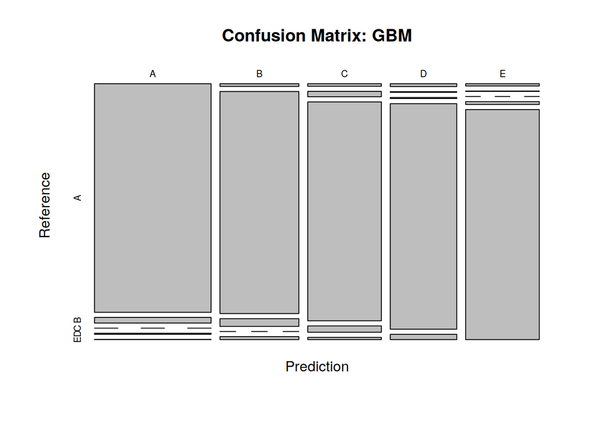

```r
plot(gbm_CM$table, main = "Confusion Matrix: GBM")
```

The GBM had an accuracy of 0.9572608 and an out-of-sample error rate of 0.0427392.

## Random Forest

Since the GBM only had an accuracy of ~ 0.95, we will next use a random forest model to attempt to improve accuracy.

```r
rf_mod <- train(classe ~ ., data = train_clean, method = "rf")
```

Using the random forest model to predict the `classe` of the `test_part` of the training data:

```r
rf_pred <- predict(rf_mod, test_part)
```

Using a confusion matrix to evaluate the performance of the random forest model:

```r
(rf_CM <- confusionMatrix(rf_pred, test_part$classe))
```

```
#> Confusion Matrix and Statistics
#>
#>           Reference
#> Prediction    A    B    C    D    E
#>          A 1167    5    0    1    0
#>          B    2  790    9    0    0
#>          C    1    2  709   19    0
#>          D    1    0    0  655    6
#>          E    0    0    0    0  751
#>
#> Overall Statistics
#>
#>                Accuracy : 0.9888
#>                  95% CI : (0.9851, 0.9918)
#>     No Information Rate : 0.2844
#>     P-Value [Acc > NIR] : < 2.2e-16
#>
#>                   Kappa : 0.9859
#>  Mcnemar's Test P-Value : NA
#>
#> Statistics by Class:
#>
#>                      Class: A Class: B Class: C Class: D Class: E
#> Sensitivity            0.9966   0.9912   0.9875   0.9704   0.9921
#> Specificity            0.9980   0.9967   0.9935   0.9980   1.0000
#> Pos Pred Value         0.9949   0.9863   0.9699   0.9894   1.0000
#> Neg Pred Value         0.9986   0.9979   0.9973   0.9942   0.9982
#> Prevalence             0.2844   0.1935   0.1744   0.1639   0.1838
#> Detection Rate         0.2834   0.1918   0.1722   0.1591   0.1824
#> Detection Prevalence   0.2848   0.1945   0.1775   0.1608   0.1824
#> Balanced Accuracy      0.9973   0.9940   0.9905   0.9842   0.9960
```

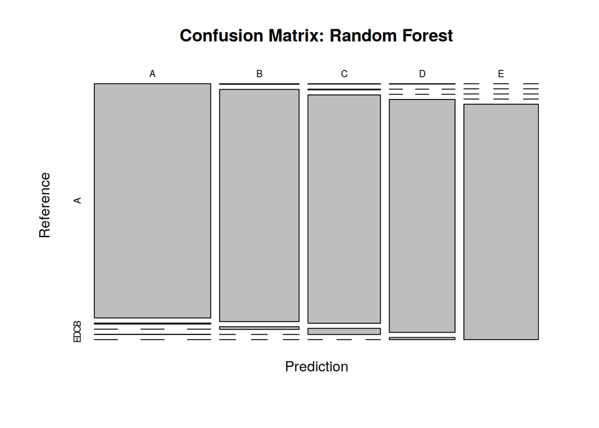

```r
plot(rf_CM$table, main = "Confusion Matrix: Random Forest")
```

The random forest model had an accuracy of 0.9888295 and an out-of-sample error rate of 0.0111705, which is better than the GBM.

## Combined Model

Finally, we will combine the predictions from the GBM and random forest model and use them to train a new combined random forest model.

```r
pred_df <- data_frame(gbm = gbm_pred, rf = rf_pred,
                     classe = test_part$classe)
combined_mod <- train(classe ~ ., data = pred_df, method = "rf")
```

Using this new combined random forest model to predict the `classe` of the `test_part` of the training data (which was used to train this new model):

```r
combined_pred <- predict(combined_mod, pred_df)
```

And, evaluating the performance of this new combined model with a confusion matrix:

```r
(combined_CM <- confusionMatrix(combined_pred, pred_df$classe))
```

```
#> Confusion Matrix and Statistics
#>
#>           Reference
#> Prediction    A    B    C    D    E
#>          A 1167    5    0    1    0
#>          B    2  790    9    0    0
#>          C    1    2  706   12    0
#>          D    1    0    3  662    6
#>          E    0    0    0    0  751
#>
#> Overall Statistics
#>
#>                Accuracy : 0.9898
#>                  95% CI : (0.9862, 0.9926)
#>     No Information Rate : 0.2844
#>     P-Value [Acc > NIR] : < 2.2e-16
#>
#>                   Kappa : 0.9871
#>  Mcnemar's Test P-Value : NA
#>
#> Statistics by Class:
#>
#>                      Class: A Class: B Class: C Class: D Class: E
#> Sensitivity            0.9966   0.9912   0.9833   0.9807   0.9921
#> Specificity            0.9980   0.9967   0.9956   0.9971   1.0000
#> Pos Pred Value         0.9949   0.9863   0.9792   0.9851   1.0000
#> Neg Pred Value         0.9986   0.9979   0.9965   0.9962   0.9982
#> Prevalence             0.2844   0.1935   0.1744   0.1639   0.1838
#> Detection Rate         0.2834   0.1918   0.1714   0.1608   0.1824
#> Detection Prevalence   0.2848   0.1945   0.1751   0.1632   0.1824
#> Balanced Accuracy      0.9973   0.9940   0.9894   0.9889   0.9960
```

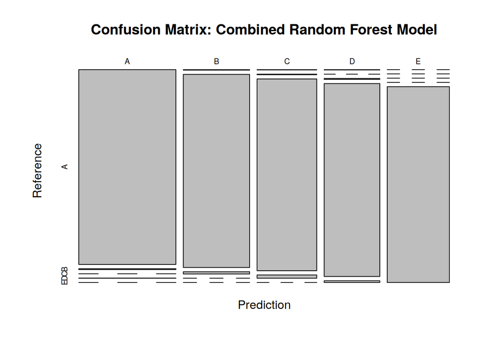

```r
plot(combined_CM$table, main = "Confusion Matrix: Combined Random Forest Model")
```

The new combined random forest model had an accuracy of 0.9898009. This combined model has slightly better accuracy than the random forest model alone on the `test_part` of the training data.

## Validate Combined Model

Since the `test_part` of the training data was used to train the combined model, it is not a good estimate of out-of-sample error. Instead, we will predict the `classe` of the `valid_part` of the training data and use that to estimate the out-of-sample error.

```r
gbm_pred_valid <- predict(gbm_mod, valid_part)
rf_pred_valid <- predict(rf_mod, valid_part)
pred_df_valid <- data_frame(gbm = gbm_pred_valid, rf = rf_pred_valid)
```

```r
combined_pred_valid <- predict(combined_mod, pred_df_valid)
```

Using a confusion matrix to evaluate the performance of the combined model on the `valid_part` of the training data:

```r
(combined_valid_CM <- confusionMatrix(combined_pred_valid, valid_part$classe))
```

```
#> Confusion Matrix and Statistics
#>
#>           Reference
#> Prediction    A    B    C    D    E
#>          A 1665    7    0    4    0
#>          B    4 1127    7    0    0
#>          C    3    4  998   23    1
#>          D    2    1   21  937    9
#>          E    0    0    0    0 1072
#>
#> Overall Statistics
#>
#>                Accuracy : 0.9854
#>                  95% CI : (0.982, 0.9883)
#>     No Information Rate : 0.2845
#>     P-Value [Acc > NIR] : < 2.2e-16
#>
#>                   Kappa : 0.9815
#>  Mcnemar's Test P-Value : NA
#>
#> Statistics by Class:
#>
#>                      Class: A Class: B Class: C Class: D Class: E
#> Sensitivity            0.9946   0.9895   0.9727   0.9720   0.9908
#> Specificity            0.9974   0.9977   0.9936   0.9933   1.0000
#> Pos Pred Value         0.9934   0.9903   0.9699   0.9660   1.0000
#> Neg Pred Value         0.9979   0.9975   0.9942   0.9945   0.9979
#> Prevalence             0.2845   0.1935   0.1743   0.1638   0.1839
#> Detection Rate         0.2829   0.1915   0.1696   0.1592   0.1822
#> Detection Prevalence   0.2848   0.1934   0.1749   0.1648   0.1822
#> Balanced Accuracy      0.9960   0.9936   0.9832   0.9826   0.9954
```

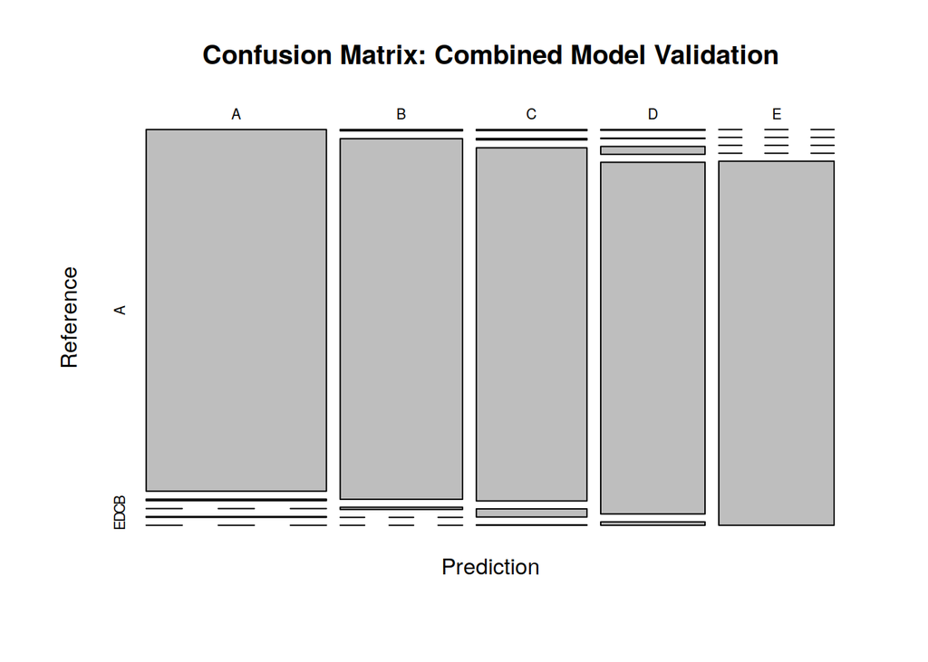

```r
plot(combined_valid_CM$table, main = "Confusion Matrix: Combined Model Validation")
```

The random forest model had an accuracy of 0.9853866 and an out-of-sample error rate of 0.0146134, which may not be an improvement over the performance of the original random forest model by itself, especially since the combined model requires the extra computation time to fit extra models.

# Predict for Test Data

Finally, we will predict the `classe` of the testing data for submission in the prediction quiz.

```r
gbm_pred_test <- predict(gbm_mod, testing_full)
rf_pred_test <- predict(rf_mod, testing_full)
pred_df_test <- data_frame(gbm = gbm_pred_test, rf = rf_pred_test)
```

```r
(combined_pred_test <- predict(combined_mod, pred_df_test))
```

```
#>  [1] B A B A A E D B A A B C B A E E A B B B
#> Levels: A B C D E
```

```r
rmarkdown::pandoc_version()
```

```
#> [1] '1.19.1'
```